# Part I - (Flights Data Exploration)

## Introduction

> This dataset reports flights in the United States, including carriers, arrival and departure delays, and reasons for delays, for the year 2007
> - What are the Characteristics of delayed flights? Are there certain destinations that are home to more delays or cancellations?
> - What are the characteristics of cancelled flights? Is it dependent on time or seasons?

> To answer this, we look at data obatined from 7453215 flights that took place in 2007

## Preliminary Wrangling

```python
# import all packages and set plots to be embedded inline
import numpy as np
import pandas as pd
import matplotlib.pyplot as plt
import seaborn as sb

%matplotlib inline
```

> Load in your dataset and describe its properties through the questions below. Try and motivate your exploration goals through this section.

```python
#  loading the dataset into a pandas dataframe
df = pd.read_csv('2007.csv')
```

```python
# high-level overview of data shape and composition
print(df.shape)
print(df.dtypes)
```

```
(7453215, 29)
Year                   int64
Month                  int64
DayofMonth             int64
DayOfWeek              int64
DepTime              float64
CRSDepTime             int64
ArrTime              float64
CRSArrTime             int64
UniqueCarrier         object
FlightNum              int64
TailNum               object
ActualElapsedTime    float64
CRSElapsedTime       float64
AirTime              float64
ArrDelay             float64
DepDelay             float64
Origin                object
Dest                  object
Distance               int64
TaxiIn                 int64
TaxiOut                int64
Cancelled              int64
CancellationCode      object
Diverted               int64
CarrierDelay           int64
WeatherDelay           int64
NASDelay               int64
SecurityDelay          int64
LateAircraftDelay      int64
dtype: object
```

## Data Wrangling

```python
#  Replacing the values of Cancelled column
df['Cancelled']= df['Cancelled'].replace([1, 0],['Yes', 'No'])
```

```python
df['Cancelled'].value_counts()
```

```
No     7292467
Yes     160748
Name: Cancelled, dtype: int64
```

```python
#  Replacing the values of Diverted column
df['Diverted']= df['Diverted'].replace([1, 0],['Yes', 'No'])
```

```python
df['Diverted'].value_counts()
```

```
No     7436036
Yes      17179
Name: Diverted, dtype: int64
```

```python
# Convert Cancelled and Diverted into cartegorical types
df['Diverted'] = df['Diverted'].astype('category')
df['Cancelled'] = df['Cancelled'].astype('category')
```

```python
# descriptive statistics for numeric values
df.describe()
```

|  | Year | Month | DayofMonth | DayOfWeek | DepTime | CRSDepTime | ArrTime | CRSArrTime | FlightNum | ActualElapsedTime | ... | ArrDelay | DepDelay | Distance | TaxiIn | TaxiOut | CarrierDelay | WeatherDelay | NASDelay | SecurityDelay | LateAircraftDelay |
| --- | --- | --- | --- | --- | --- | --- | --- | --- | --- | --- | --- | --- | --- | --- | --- | --- | --- | --- | --- | --- | --- |
| count | 7453215.0 | 7.453215e+06 | 7.453215e+06 | 7.453215e+06 | 7.292467e+06 | 7.453215e+06 | 7.275288e+06 | 7.453215e+06 | 7.453215e+06 | 7.275288e+06 | ... | 7.275288e+06 | 7.292467e+06 | 7.453215e+06 | 7.453215e+06 | 7.453215e+06 | 7.453215e+06 | 7.453215e+06 | 7.453215e+06 | 7.453215e+06 | 7.453215e+06 |
| mean | 2007.0 | 6.514876e+00 | 1.572589e+01 | 3.933804e+00 | 1.339221e+03 | 1.330596e+03 | 1.482105e+03 | 1.495392e+03 | 2.188099e+03 | 1.263223e+02 | ... | 1.019218e+01 | 1.139914e+01 | 7.198058e+02 | 6.691984e+00 | 1.630015e+01 | 3.865236e+00 | 7.700904e-01 | 3.783702e+00 | 2.373553e-02 | 5.099134e+00 |
| std | 0.0 | 3.425117e+00 | 8.781154e+00 | 1.992267e+00 | 4.798528e+02 | 4.647080e+02 | 5.072241e+02 | 4.815902e+02 | 1.971958e+03 | 7.118009e+01 | ... | 3.930774e+01 | 3.614189e+01 | 5.623051e+02 | 5.151351e+00 | 1.183396e+01 | 2.084240e+01 | 9.619547e+00 | 1.617670e+01 | 1.084995e+00 | 2.127753e+01 |
| min | 2007.0 | 1.000000e+00 | 1.000000e+00 | 1.000000e+00 | 1.000000e+00 | 0.000000e+00 | 1.000000e+00 | 0.000000e+00 | 1.000000e+00 | 1.200000e+01 | ... | -3.120000e+02 | -3.050000e+02 | 1.100000e+01 | 0.000000e+00 | 0.000000e+00 | 0.000000e+00 | 0.000000e+00 | 0.000000e+00 | 0.000000e+00 | 0.000000e+00 |
| 25% | 2007.0 | 4.000000e+00 | 8.000000e+00 | 2.000000e+00 | 9.300000e+02 | 9.300000e+02 | 1.107000e+03 | 1.115000e+03 | 5.900000e+02 | 7.600000e+01 | ... | -9.000000e+00 | -4.000000e+00 | 3.190000e+02 | 4.000000e+00 | 1.000000e+01 | 0.000000e+00 | 0.000000e+00 | 0.000000e+00 | 0.000000e+00 | 0.000000e+00 |
| 50% | 2007.0 | 7.000000e+00 | 1.600000e+01 | 4.000000e+00 | 1.329000e+03 | 1.322000e+03 | 1.513000e+03 | 1.520000e+03 | 1.509000e+03 | 1.080000e+02 | ... | 0.000000e+00 | 0.000000e+00 | 5.690000e+02 | 5.000000e+00 | 1.400000e+01 | 0.000000e+00 | 0.000000e+00 | 0.000000e+00 | 0.000000e+00 | 0.000000e+00 |
| 75% | 2007.0 | 9.000000e+00 | 2.300000e+01 | 6.000000e+00 | 1.733000e+03 | 1.720000e+03 | 1.911000e+03 | 1.906000e+03 | 3.553000e+03 | 1.560000e+02 | ... | 1.400000e+01 | 1.100000e+01 | 9.460000e+02 | 8.000000e+00 | 1.900000e+01 | 0.000000e+00 | 0.000000e+00 | 0.000000e+00 | 0.000000e+00 | 0.000000e+00 |
| max | 2007.0 | 1.200000e+01 | 3.100000e+01 | 7.000000e+00 | 2.400000e+03 | 2.359000e+03 | 2.400000e+03 | 2.400000e+03 | 9.602000e+03 | 1.270000e+03 | ... | 2.598000e+03 | 2.601000e+03 | 4.962000e+03 | 5.450000e+02 | 5.300000e+02 | 2.580000e+03 | 1.429000e+03 | 1.386000e+03 | 3.820000e+02 | 1.031000e+03 |

8 rows × 22 columns

### Variable Names, and description

```python
# Load in  the variable names
variables= pd.read_csv('variables table.csv', index_col=0)
```

```python
variables.set_index('Name', inplace=True)
```

```python
# getting the variable columns
variables
```

| Name | Description |
| --- | --- |
| Year | 1987-2008 |
| Month | 12-Jan |
| DayofMonth | 31-Jan |
| DayOfWeek | 1 (Monday) - 7 (Sunday) |
| DepTime | actual departure time (local, hhmm) |
| CRSDepTime | scheduled departure time (local, hhmm) |
| ArrTime | actual arrival time (local, hhmm) |
| CRSArrTime | scheduled arrival time (local, hhmm) |
| UniqueCarrier | unique carrier code |
| FlightNum | flight number |
| TailNum | plane tail number |
| ActualElapsedTime | in minutes |
| CRSElapsedTime | in minutes |
| AirTime | in minutes |
| ArrDelay | arrival delay, in minutes |
| DepDelay | departure delay, in minutes |
| Origin | origin IATA airport code |
| Dest | destination IATA airport code |
| Distance | in miles |
| TaxiIn | taxi in time, in minutes |
| TaxiOut | taxi out time in minutes |
| Cancelled | was the flight cancelled? |
| CancellationCode | reason for cancellation (A = carrier, B = weat... |
| Diverted | 1 = yes, 0 = no |
| CarrierDelay | in minutes |
| WeatherDelay | in minutes |
| NASDelay | in minutes |
| SecurityDelay | in minutes |
| LateAircraftDelay | in minutes |

```python
# loading in the names of the unique carriers
carriers_df = pd.read_csv('carriers.csv', index_col='Code')
carriers_df.sample(10)
```

| Code | Description |
| --- | --- |
| KAT | Katmai Air |
| THO | Thorson Aviation |
| CYQ | Corse Air International |
| E9 | Boston-Maine Airways |
| ONQ | Nunasi-Central Airlines Ltd. |
| KTQ | Turks Air Ltd. |
| SOL | Soonair Lines Inc. |
| J7 | Valujet Airlines Inc. |
| IMP | Imperial Airlines Inc. |
| BBQ | Balair Ag |

```python
carriers_df.loc['WN']
```

```
Description    Southwest Airlines Co.
Name: WN, dtype: object
```

```python
# loading in the plane data
plane_data = pd.read_csv('plane-data.csv')
```

```python
df.head(10)
```

|  | Year | Month | DayofMonth | DayOfWeek | DepTime | CRSDepTime | ArrTime | CRSArrTime | UniqueCarrier | FlightNum | ... | TaxiIn | TaxiOut | Cancelled | CancellationCode | Diverted | CarrierDelay | WeatherDelay | NASDelay | SecurityDelay | LateAircraftDelay |
| --- | --- | --- | --- | --- | --- | --- | --- | --- | --- | --- | --- | --- | --- | --- | --- | --- | --- | --- | --- | --- | --- |
| 0 | 2007 | 1 | 1 | 1 | 1232.0 | 1225 | 1341.0 | 1340 | WN | 2891 | ... | 4 | 11 | No | NaN | No | 0 | 0 | 0 | 0 | 0 |
| 1 | 2007 | 1 | 1 | 1 | 1918.0 | 1905 | 2043.0 | 2035 | WN | 462 | ... | 5 | 6 | No | NaN | No | 0 | 0 | 0 | 0 | 0 |
| 2 | 2007 | 1 | 1 | 1 | 2206.0 | 2130 | 2334.0 | 2300 | WN | 1229 | ... | 6 | 9 | No | NaN | No | 3 | 0 | 0 | 0 | 31 |
| 3 | 2007 | 1 | 1 | 1 | 1230.0 | 1200 | 1356.0 | 1330 | WN | 1355 | ... | 3 | 8 | No | NaN | No | 23 | 0 | 0 | 0 | 3 |
| 4 | 2007 | 1 | 1 | 1 | 831.0 | 830 | 957.0 | 1000 | WN | 2278 | ... | 3 | 9 | No | NaN | No | 0 | 0 | 0 | 0 | 0 |
| 5 | 2007 | 1 | 1 | 1 | 1430.0 | 1420 | 1553.0 | 1550 | WN | 2386 | ... | 2 | 7 | No | NaN | No | 0 | 0 | 0 | 0 | 0 |
| 6 | 2007 | 1 | 1 | 1 | 1936.0 | 1840 | 2217.0 | 2130 | WN | 409 | ... | 5 | 7 | No | NaN | No | 46 | 0 | 0 | 0 | 1 |
| 7 | 2007 | 1 | 1 | 1 | 944.0 | 935 | 1223.0 | 1225 | WN | 1131 | ... | 4 | 9 | No | NaN | No | 0 | 0 | 0 | 0 | 0 |
| 8 | 2007 | 1 | 1 | 1 | 1537.0 | 1450 | 1819.0 | 1735 | WN | 1212 | ... | 5 | 7 | No | NaN | No | 20 | 0 | 0 | 0 | 24 |
| 9 | 2007 | 1 | 1 | 1 | 1318.0 | 1315 | 1603.0 | 1610 | WN | 2456 | ... | 5 | 8 | No | NaN | No | 0 | 0 | 0 | 0 | 0 |

10 rows × 29 columns

```python
# Dropping the clumns uneccessary in my findings
df.drop(['Origin', 'AirTime', 'ArrTime', 'CRSArrTime', 'DayofMonth', 'Year', 'FlightNum', 'TailNum', 'TaxiIn', 'TaxiOut'], axis = 1, inplace = True)
```

```python
print(f'After wrangling, the dataset contains {df.shape} rows and columns respectively')
```

```
After wrangling, the dataset contains (7453215, 19) rows and columns respectively
```

### What is the structure of your dataset?

There are 7453215, rows with 19 feautures. The column names are described in the `variables` DataFrame above

### What is/are the main feature(s) of interest in your dataset?

> The main points of interest are feautures that are characteristics of, or results in delayed/cancelled flights Arrival delay: Arrival delay equals the difference of the actual arrival time minus the scheduled arrival time. A flight is considered on-time when it arrives less than 15 minutes after its published arrival time.
> - The proportion of delayed/cancelled flights in different seasons of the year
> - Destination or arrival cities that are home to more delays or cancellations?
> - Airline systems with higher delays

### What features in the dataset do you think will help support your investigation into your feature(s) of interest?

> - Months --I expect that weather which is dependent on the seasn of the year, will have the strongest effect on whether or not a flight is cancelled
> - Unique Carriers -- and certain carriers may be notorious for having delays,
> - Destinations --those areas with a far destination may have a high probability of being delayed, and;
> - departure time-- Will affect whether or not a flight experiences delay

## Univariate Exploration

- First, I examine the main variable of interest, month.

```python
# defining a function that would add a title to all the plots in this notebook
def chart_label(title):
    return plt.title(title)
```

### In which month did the flights take place?

```
Text(0.5,1,'Monthly flights occurrence')
```

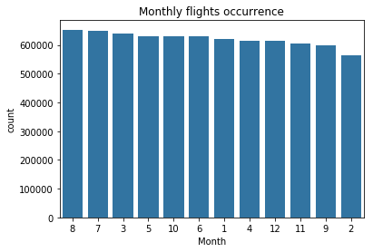

```python
# inspecting the months column
base_color = sb.color_palette()[0]
month_order = df['Month'].value_counts().index
# Use the `color` argument
sb.countplot(data=df, x='Month', color=base_color, order=month_order);
chart_label('Monthly flights occurrence')
```

The counts of flight taking place on a monthly basis are roughly similar, but August is slightly higher, and February experiences the least amount of flight.

### What is the distribution of carriers in the dataset?

```
Text(0.5,1,'Distribution of Unique Carriers in 2007')
```

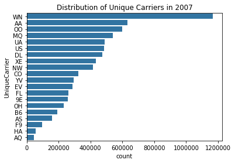

```python
# plotting the distribution of carriers
base_color = sb.color_palette()[0]
carrier_order=df['UniqueCarrier'].value_counts().index
sb.countplot(data=df, y='UniqueCarrier', color=base_color, order=carrier_order);
chart_label('Distribution of Unique Carriers in 2007')
```

The most popular carrier used in this dataset is the `WN`--Southwest Airlines Co. followed by AA--American Airlines Inc.

### What is the distribution of canceled flights?

```
Text(0.5,1,'Proportion of Cancelled flights')
```

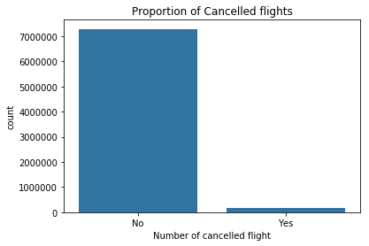

```python
base_color = sb.color_palette()[0]
sb.countplot(data=df, x='Cancelled', color=base_color);
plt.xlabel('Number of cancelled flight')
chart_label('Proportion of Cancelled flights')
```

There are very few cancelled flights recorded in the dataset

### What is the distribution of Diverted Flights?

```
Text(0.5,1,'Proprtion of Diverted flights')
```

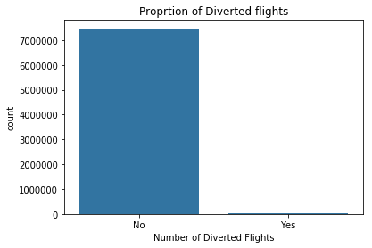

```python
base_color = sb.color_palette()[0]
sb.countplot(data=df, x='Diverted', color=base_color);
plt.xlabel('Number of Diverted Flights')
chart_label('Proprtion of Diverted flights')
```

There's only a small percentage of flights that actually experienced diversion

### What day of the week are the flights taking place in

```python
# getting the order for the graph below
week_order = df['DayOfWeek'].value_counts().index
```

```
Text(0.5,1,'Proportion of flights per day')
```

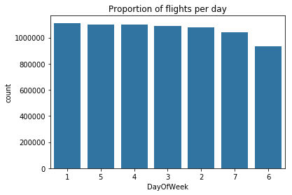

```python
# plotting the distribution of flight number per day
base_color = sb.color_palette()[0]
sb.countplot(data=df, x='DayOfWeek', color=base_color, order=week_order);
chart_label('Proportion of flights per day')
```

The least amount of flights occurred on Saturdays, and Sundays(DayofWeek 1 (Monday) - 7 (Sunday))

### What is the percentage of missing data in the dataset?

```python
# getting the missing values by columns
df.isna().sum()
```

```
Month                      0
DayOfWeek                  0
DepTime               160748
CRSDepTime                 0
UniqueCarrier              0
ActualElapsedTime     177927
CRSElapsedTime           994
ArrDelay              177927
DepDelay              160748
Dest                       0
Distance                   0
Cancelled                  0
CancellationCode     7292466
Diverted                   0
CarrierDelay               0
WeatherDelay               0
NASDelay                   0
SecurityDelay              0
LateAircraftDelay          0
dtype: int64
```

#### Plotting a graph of missing data

```python
# Let's drop the column that do not have any NaN/None values
na_counts = df.drop(['Month', 'DayOfWeek','CRSDepTime', 'UniqueCarrier', 'Dest', 'Distance', 'Cancelled', 'Diverted', 'CarrierDelay', 'WeatherDelay', 'NASDelay', 'SecurityDelay','LateAircraftDelay'], axis=1).isna().sum()
print(na_counts)
```

```
DepTime               160748
ActualElapsedTime     177927
CRSElapsedTime           994
ArrDelay              177927
DepDelay              160748
CancellationCode     7292466
dtype: int64
```

```
Text(0.5,1,'Proportion of Missing values')
```

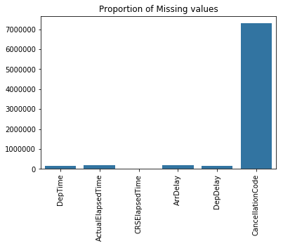

```python
# Ref: Udacity classroom
base_color = sb.color_palette()[0]
sb.barplot(na_counts.index.values, na_counts, color=base_color)

# Setting the tick locations and labels
plt.xticks(rotation=90)
chart_label('Proportion of Missing values')
```

Cancellation code has a high number of missing values, and this makes sence, because only a small volume of flights are cancelled, and since it is a very useful feauture, will work with it.

### What is the distribution of cancellation code

```python
df['CancellationCode'].value_counts()
```

```
A    66779
B    61936
C    31995
D       39
Name: CancellationCode, dtype: int64
```

```
(-1.1186385438271254,
 1.1244869920715703,
 -1.1128809319321946,
 1.1302446039665011)
```

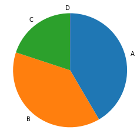

```python
# Udacity classroom
# Getting the cancellation code
sorted_counts = df['CancellationCode'].value_counts()

plt.pie(sorted_counts, labels = sorted_counts.index, startangle = 90, counterclock = False);

plt.axis('square')
```

There is no clear distinction for `CancellationCode` D Below, I use a bar graph to better understand the distribution

```
Text(0.5,1,'Distribution of Cancellation Code')
```

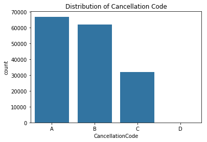

```python
# https://github.com/cnegrelli/Data_Visualization/blob/master/exploration.ipynb
base_color = sb.color_palette()[0]
sb.countplot(data=df, x='CancellationCode', color=base_color)
chart_label('Distribution of Cancellation Code')
```

CancellationCode: reason for cancellation (A = carrier, B = weather, C = NAS, D = security)

- The graph shows that the most frequent reason for cancellation is the carrier, followed by weather
- This results in futher questions, which carriers are being cancelled, aNd in what mnths of the year do they experience more cancellations

> **Rubric Tip**: Visualizations should depict the data appropriately so that the plots are easily interpretable. You should choose an appropriate plot type, data encodings, and formatting as needed. The formatting may include setting/adding the title, labels, legend, and comments. Also, do not overplot or incorrectly plot ordinal data.

### What is the distribution of flights that are delayed

```
Text(0.5,1,'Distribution of delayed Flights')
```

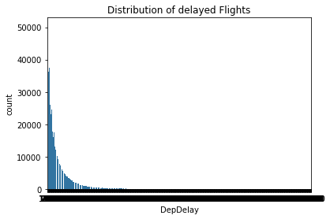

```python
delayed_flights = df[df['DepDelay'] > 15]
# getting plot of delayed
base_color = sb.color_palette()[0]
sb.countplot(data=delayed_flights, x='DepDelay', color=base_color);
chart_label('Distribution of delayed Flights')
```

A flight arriving or departing 15 minutes or more after the scheduled time is referred to as a late flight, so departure delays greater than 15 are categorized as delayed flights. This graph is right skewed, with a long tail, and the points are hard to read

### What is the distribution of months with Cancelled Flights

```
Text(0.5,1,'Months with Cancelled Flights')
```

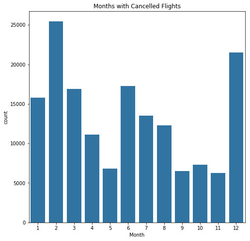

```python
#Getting a subset of original dataframe that contains only cancellations
cancel_code = ["A","B","C","D"]
df_query  = df.loc[df['CancellationCode'].isin(cancel_code)]

base_color=sb.color_palette()[0]
plt.figure(figsize=(8,8))
sb.countplot(data=df_query, x='Month', color=base_color)
chart_label('Months with Cancelled Flights')
```

February and december had high cancellations

### Which UniqueCarriers are being cancelled?

```python
#Getting a subset of original dataframe that contains only cancellations
cancel_code = ["A","B","C","D"]
df_query  = df.loc[df['CancellationCode'].isin(cancel_code)]
```

```
Text(0.5,1,'Distribution of Cancelled Airlines')
```

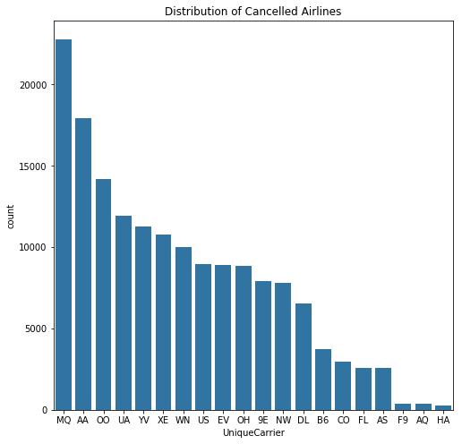

```python
#Saving value counts for various carriers
canceled=df_query['UniqueCarrier'].value_counts()

base_color=sb.color_palette()[0]
plt.figure(figsize=(8,8))
sb.countplot(data=df_query, x='UniqueCarrier', color=base_color, order=canceled.index);
chart_label('Distribution of Cancelled Airlines')
```

MQ, AA, and OO are the top three UniqueCarriers with cancellations. This is cancellations for all four categories. But we must remember, that the most common cause of cancellations are Carrier related. WN has a lower amount of cancelled flights compared to the volume of flights occurring in it.

### What unique carriers are experiencing more Departure delays

```
Text(0.5,1,'Distribution of Delayed Airlines')
```

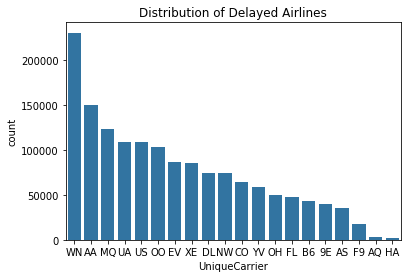

```python
# getting the orders for the graph below
delays=delayed_flights['UniqueCarrier'].value_counts()
base_color = sb.color_palette()[0]
sb.countplot(data=delayed_flights, x='UniqueCarrier', color=base_color, order=delays.index);
chart_label('Distribution of Delayed Airlines')
```

WN, AA, AND MQ are the Carriers that experience the most delays before departures. WN and AA has the largest volume of flights recorded.

### Distribution of Destinations with the most delays

```
Text(0.5,1,'Distribution of Delays by Destination')
```

[figure not shown]

```python
delayed_dest = delayed_flights['Dest'].value_counts().head(10).index
base_color = sb.color_palette()[0]
sb.countplot(data=delayed_flights, x=delayed_dest, color=base_color);
chart_label('Distribution of Delays by Destination')
```

Since there are a lot of destinations, i looked at the top 10 These are the top 10 destinations that experience departure delays

### What is the distribution of destinations that are canceled

```
Text(0.5,1,'Distribution of Cancelled Destinations')
```

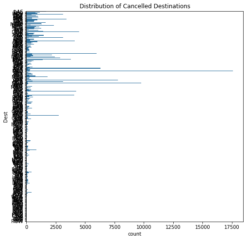

```python
# countplot of destinations that are canceled
base_color=sb.color_palette()[0]
plt.figure(figsize=(8,8))
sb.countplot(data=df_query, y='Dest', color=base_color);
chart_label('Distribution of Cancelled Destinations')
```

No meaningful insights can be obtained from this plot

### Getting the Top Cancelled Destinations

```python
# getting the head of Cancelled destinations
canceled_dest = df_query['Dest'].value_counts().head(10).index
```

```
Text(0.5,1,'Top ten cancelled destinations')
```

[figure not shown]

```python
# countplot of destinations that are canceled
base_color=sb.color_palette()[0]
plt.figure(figsize=(8,8))
sb.countplot(data=df_query, x=canceled_dest, color=base_color);
chart_label('Top ten cancelled destinations')
```

### What are the top destinations that experience departure delays?

```
Text(0.5,1,'Top Delayed Destinations')
```

[figure not shown]

```python
delayed_dest = delayed_flights['Dest'].value_counts().head(10).index
base_color = sb.color_palette()[0]
sb.countplot(data=delayed_flights, x=delayed_dest, color=base_color)
chart_label('Top Delayed Destinations')
```

### What is the distribution of Expected Departure Time ?

```
Text(0.5,1,'Distribution of Depature Time')
```

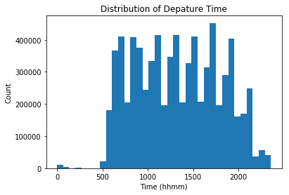

```python
# PLOtTiNG graPH Of ExPected dePARtURE tIMe
plt.hist(data = df, x = 'CRSDepTime', bins = 35);
plt.xlabel('Time (hhmm)')
plt.ylabel('Count')
plt.title('Distribution of Depature Time')
```

The largest number of flights is expected to take place between 5PM but there are hourly peaks every other hour from 5AM. After 7pm, the volume of flights drop, till 5AM the next Day Further question? Is there any relationship between expected departure time and actual departure time

### What is the distribution of distance in the data set

```
Text(0.5,1,'Distribution of Distance')
```

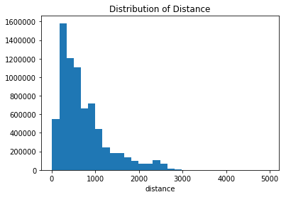

```python
plt.hist(data = df, x = 'Distance', bins=30)
plt.xlabel('distance')
chart_label('Distribution of Distance')
```

The distribution of data on distance is right skewed, with most of the flights in the data set are of a distance less than 1000mile from the origin

### What is the distribution of distance among cancelled flights

```python
dfCancelled = df[df['Cancelled']=='Yes']
```

```
Text(0.5,1,'Distribution of Cancelled Distance')
```

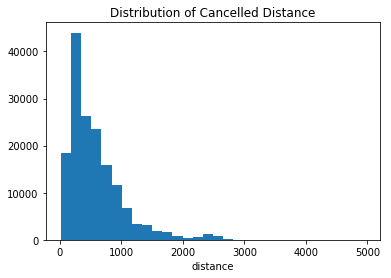

```python
plt.hist(data = dfCancelled, x = 'Distance', bins=30)
plt.xlabel('distance')
chart_label('Distribution of Cancelled Distance')
```

Of the total number of flights that were canceled, the majority of the distance was between 100 - 1000miles

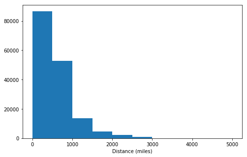

```python
# start with a standard-scaled plot
binsize = 500
bins = np.arange(0, dfCancelled['Distance'].max()+binsize, binsize)

plt.figure(figsize=[8, 5])
plt.hist(data = dfCancelled, x = 'Distance', bins = bins)
plt.xlabel('Distance (miles)')
plt.show()
```

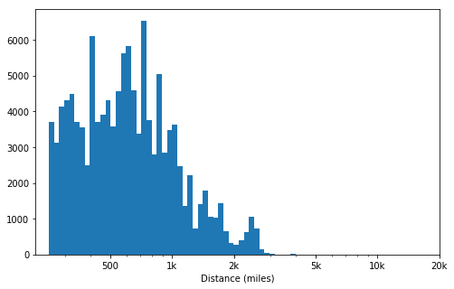

```python
# there's a long tail in the distribution, so let's put it on a log scale instead
log_binsize = 0.025
bins = 10 ** np.arange(2.4, np.log10(dfCancelled['Distance'].max())+log_binsize, log_binsize)

plt.figure(figsize=[8, 5])
plt.hist(data = dfCancelled, x = 'Distance', bins = bins)
plt.xscale('log')
plt.xticks([500, 1e3, 2e3, 5e3, 1e4, 2e4], [500, '1k', '2k', '5k', '10k', '20k'])
plt.xlabel('Distance (miles)')
plt.show()
```

### Discuss the distribution(s) of your variable(s) of interest. Were there any unusual points? Did you need to perform any transformations?

- The least amount of flight monthly was recorded in february. This is most likely a function of the weather, Or as a result of the number of days in february compared with other months?. Other than this, there weren't much differences in the monthly volume of flights. It would be im portant to compute the mnthly delay patterns, and reasons
- There weren't must changes in number of flights on a daily basis.
- Airline carriers such as AA had both high level of cancellation and departure delays

### Of the features you investigated, were there any unusual distributions? Did you perform any operations on the data to tidy, adjust, or change the form of the data? If so, why did you do this?

- Surprisingly, WN, a UniqueCarrier with the highest volume of flights had a low record of cancelled flights especially when compared to AA which had a high volume of flights, and a high volume of both cancelled and delayed flights
- I changed the `Cancelled` and `Diverted` columns into categorical datatypes
- I subsetted the data, and selected variables where the departure delays were greater than 15. This is to assess late flights, which generally have arrival or departure time more than 15minutes the expected time respectively
- I dropped some uneccessary columns

## Bivariate Exploration

> In this section, I investigated the relationships between pairs of variables in the data.

### What relationship exists between distance and Arrival Delay

```
Text(0.5,0,'ArrDelay')
```

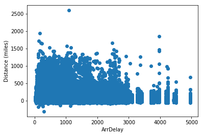

```python
# creating a scatter plot of distance and ArrDelay
plt.scatter(data=df, x='Distance', y='ArrDelay')
plt.ylabel('Distance (miles)')
plt.xlabel('ArrDelay')
```

I Continued inspecting the characteristics f delayed flights, comparing the effects that distance t be cvered had on arrival delay. I used jitter on the x-axis below to better visualize this plot

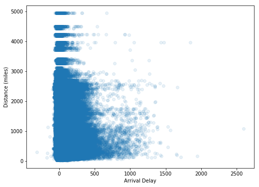

```python
# REF: Udacity Classrom
plt.figure(figsize = [18, 6])
plt.subplot(1, 2, 1)
sb.regplot(data = df, y = 'Distance', x = 'ArrDelay', x_jitter=0.04, scatter_kws={'alpha':1/10}, fit_reg=False)
plt.ylabel('Distance (miles)')
plt.xlabel('Arrival Delay');
```

### What is the correlation between Arrival Delay and Departure Delay

```
Text(0.5,1,'Departure delay by Arrival delay')
```

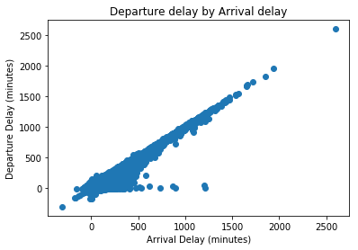

```python
plt.scatter(data=df, x='ArrDelay', y='DepDelay')
plt.xlabel('Arrival Delay (minutes)')
plt.ylabel('Departure Delay (minutes)')
chart_label('Departure delay by Arrival delay')
```

Looking at the characteristics of delay, both arrival and departures, There is a strong positive correlation between arrival delay and departure delay.

### What relationship exists between actual elapsed time, and the Expected elapsed time?

```
Text(0,0.5,'Expected Elapsed Time')
```

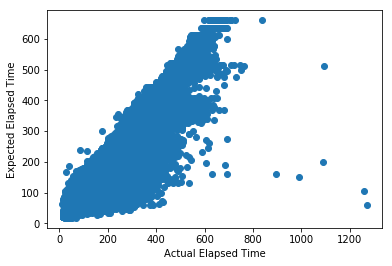

```python
plt.scatter(data=df, x='ActualElapsedTime', y= 'CRSElapsedTime')
plt.xlabel('Actual Elapsed Time')
plt.ylabel('Expected Elapsed Time')
```

There is a positive correlation between the actual elapsed time and the expected elapsed time. As the expected elapsed time increases, the actual elapsed time also increases

### What relationship exists between Elapsed Time and Distance?

```
Text(0.5,1,'Distance (miles) by Elapsed Time')
```

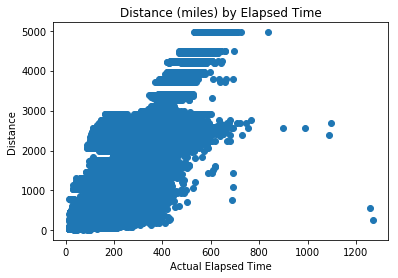

```python
plt.scatter(data=df, x='ActualElapsedTime', y= 'Distance')
plt.xlabel('Actual Elapsed Time')
plt.ylabel('Distance')
chart_label('Distance (miles) by Elapsed Time')
```

As the distance of a trip increases, the actual Elapsed Time also increases...Although there are a few outliers, where the time spent is greater than the corresponding distance

### Is there any relationship between Distance and Departure Delay?

Do flights with a longer distance have a higher tendency to be delayed before leaving

```
Text(0.5,1,'Departure delay by Distance (miles) ')
```

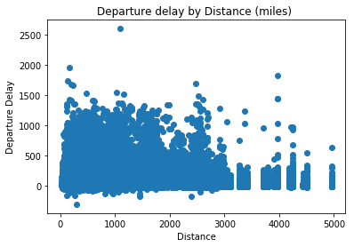

```python
plt.scatter(data=df, x='Distance', y= 'DepDelay')
plt.ylabel('Departure Delay')
plt.xlabel('Distance')
chart_label('Departure delay by Distance (miles) ')
```

There are more departure delays among distances that are less than 3000 miles. Beyond that, the departure delays decreases

### Which airline experiences more delay

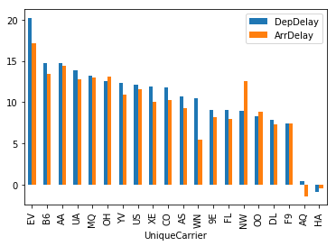

```
Text(0.5,1,'Distribution of Delays for each Unique Carrier')
```

[figure not shown]

```python
# https://shawnemhe.github.io/udacity-data-analyst/p6/python_eda/python_eda.html
# I grouped by airlines, and got the average departure and arrival delays
df.groupby('UniqueCarrier').agg({'DepDelay':'mean', 'ArrDelay':'mean'}).sort_values('DepDelay', ascending=False).plot.bar()
chart_label('Distribution of Delays for each Unique Carrier')
plt.show()
```

- EV: Atlantic Southeast Airlines, B6: JetBlue Airways, AA: American Airlines Inc. are the top airlines with delays
- NW: Northwest Airlines Inc. had a particularly high arrival delay
- AQ: Aloha Airlines Inc. had early arrivals,
- HA: Hawaiian Airlines Inc. Departed, and arrived ahead of schedule